# Making Maps

```r
library(sf)
library(tidyverse)
library(ggplot2)
library(tigris)
library(dplyr)
library(readr)
library(colorspace)
library(colorblindr)
library(ggokabeito)
```

1.) Identify a **continuous** variable of interest to you that is distributed geographically (across U.S. states, U.S. counties, precincts within a state, countries in the world, etc.). Choose a variable that is not simply a proxy for population density

```r
US_Income_data <-read_csv("US_Income.csv")
```

a.) Using a simple feature dataframe, generate a map of the *geography* you will be mapping (U.S. states, U.S. counties, precincts within a state/country, countries in the world, etc.). This will be a blank map.

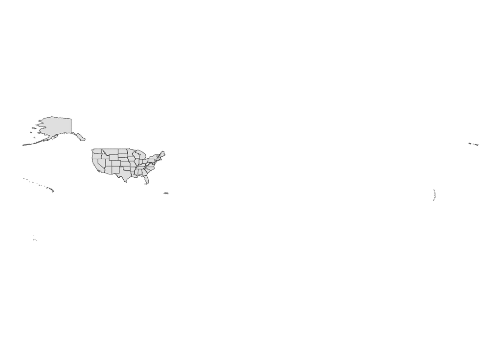

```r
US_Map <-st_read("tl_2021_us_state/tl_2021_us_state.shp")
ggplot(US_Map) +
  geom_sf() +
  theme_void()
```

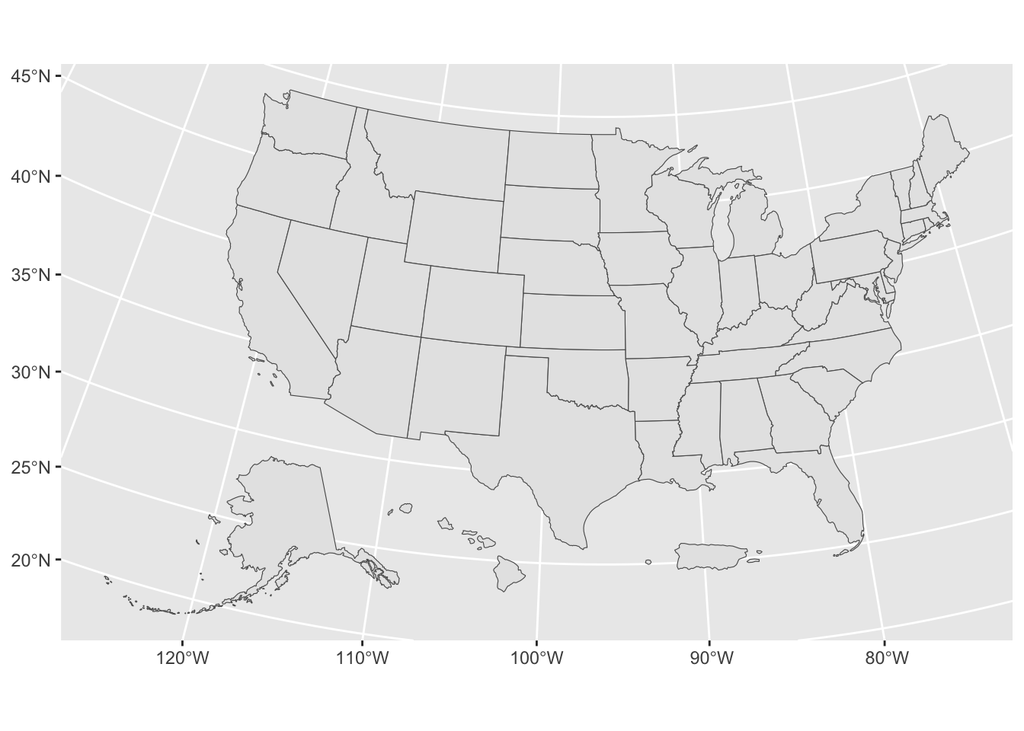

```r
US_Map <- tigris::states(cb = TRUE,
                     resolution = "20m") |>
  tigris::shift_geometry()
ggplot(US_Map) + geom_sf()
```

b.) Using `left_join()`, join some data to map to your simple feature dataframe, and generate a thematic map/choropleth of your variable using a **gradient** color scheme. Describe the patterns in your map. What story are you communicating with your map? Does the map effectively communicate your story? Why or why not?

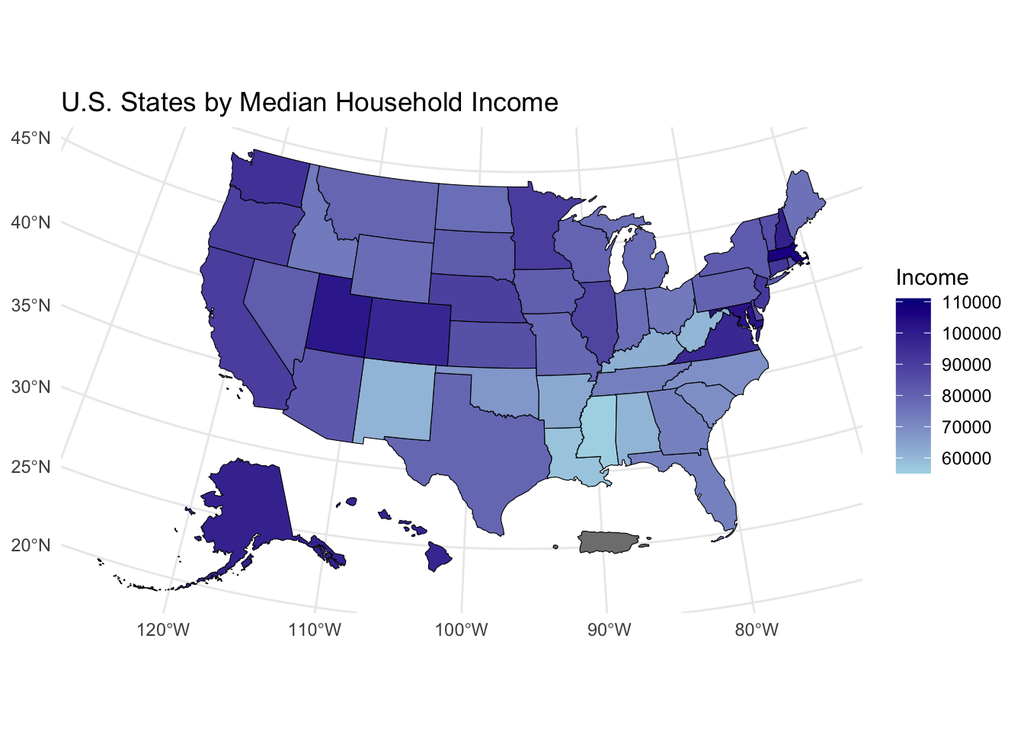

```r
us_states_income <-left_join(US_Map,US_Income_data, by = c("NAME"="States"))
ggplot(data = us_states_income) +
  geom_sf(aes(fill = Income), color = "black") +
  scale_fill_gradient(low = "lightblue", high = "darkblue") +
  theme_minimal() +
  labs(title = "U.S. States by Median Household Income", fill = "Income")
```

- The pattern demonstrated in this map is a high range of 80000 to 9000 Income states. Many states in the southern region of the U.S have lower income’s per household and the ones in the northern regions have higher incomes. The story I’m trying to describe is the income distributions and inequalities in the United States. This map does help describe the income inequalities in the U.S there are some states with the average income per house hold twice as large then other states.

c.) Modify your thematic map in 1b but changing from a gradient color scheme to a **classed** color scheme. How does the new choice affect the map? Does the original or modified approach better represent the data? Why?

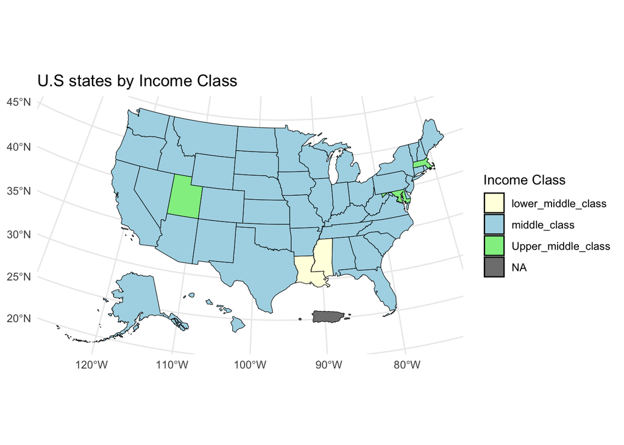

```r
us_states_income$income_class <- cut(us_states_income$Income,
                                     breaks = c(45000,60000,100000,110000),
                                     labels = c("lower_middle_class","middle_class","Upper_middle_class"))

ggplot(data = us_states_income)+
  geom_sf(aes(fill=income_class), color = "black")+
  scale_fill_manual(values = c("lower_middle_class"="lightyellow", "middle_class"= "lightblue", "Upper_middle_class"= "lightgreen"))+
  theme_minimal()+
  labs(
    title = "U.S states by Income Class",
    fill = "Income Class"
  )
```

- This new approach effects my map by making the income distribution look more equal through out the United States. The original approach better represents the data because it shows the larger range of income distribution while this model is less detailed showing a broader range.

2.) Identify a **factor/string** variable of interest to you that is distributed geographically across a *different* geography than you used in question 1. Again choose a variable that is not simply a proxy for population density.

```r
EU_Crude_birth <- read_csv("EU_Crude_birth.csv")
```

a.) Using a simple feature dataframe, generate a map of the *geography* you will be mapping (U.S. states, U.S. counties, precincts within a state/country, countries in the world, etc.). This will be a blank map.

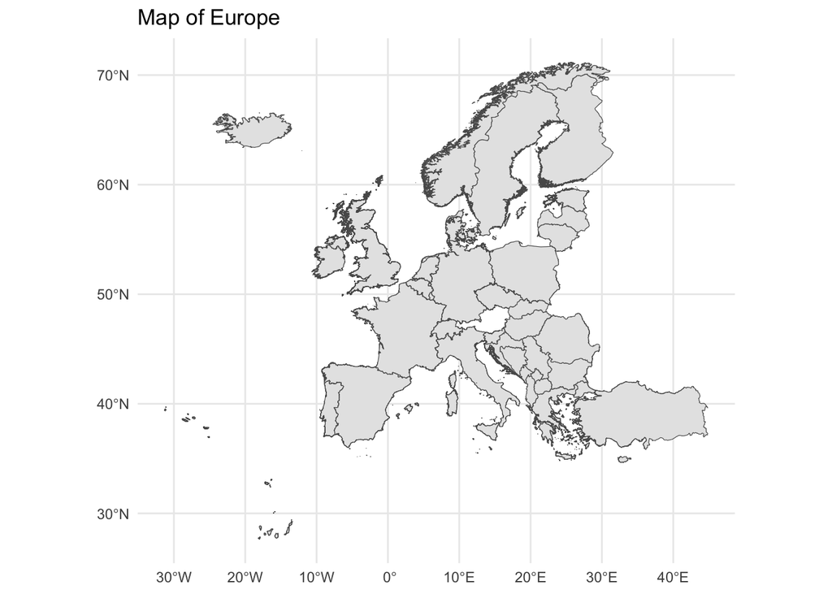

```r
Europe_map <-st_read("Europe/Europe_merged.shp")
ggplot(Europe_map)+
  geom_sf() +
  theme_minimal() +
  labs(
    title = "Map of Europe"
  )
```

b.) Using `left_join()`, join some data to map to your simple feature dataframe, and generate a thematic map/choropleth of your variable using a **sequential** color scheme. Describe the patterns in your map. What story are you communicating with your map? Does the map effectively communicate your story? Why or why not?

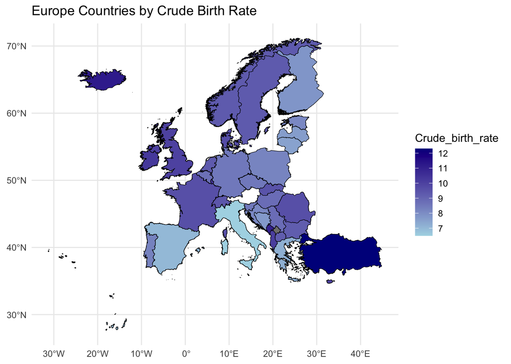

```r
Europe_Birth_Map <-left_join(Europe_map, EU_Crude_birth, by = c("COUNTRY"="Country"))
ggplot(data = Europe_Birth_Map) +
  geom_sf(aes(fill = Crude_birth_rate), color = "black") +
  scale_fill_gradient(low = "lightblue", high = "darkblue") +
  theme_minimal() +
  labs(title = "Europe Countries by Crude Birth Rate", fill = "Crude_birth_rate")
```

c.) Modify your thematic map in 2b, changing from a sequential color scheme to a **divergent** color scheme. How does the new choice affect the map? Does the original or modified approach better represent the data? Why?

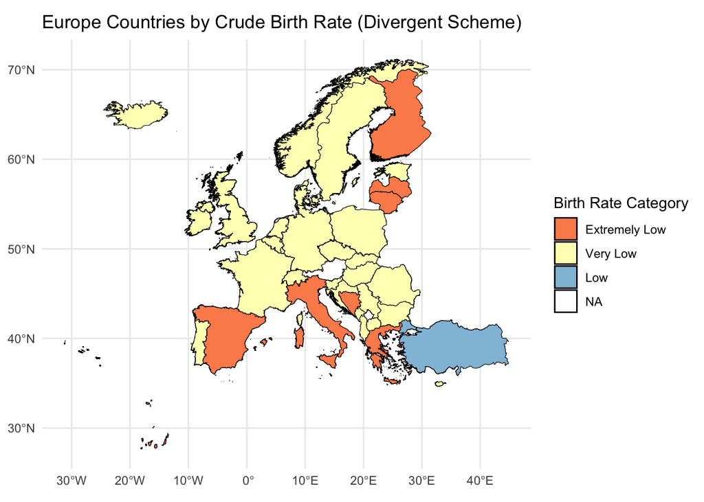

```r
Europe_Birth_Map <- Europe_Birth_Map |>
  mutate(Birth_Rate_Category = cut(
    Crude_birth_rate,
    breaks = c(0, 8, 12, 16, 20, 25, Inf),
    labels = c("Extremely Low", "Very Low", "Low", "Moderate", "High", "Very High"),
    ordered_result = TRUE
  ))

ggplot(data = Europe_Birth_Map) +
  geom_sf(aes(fill = Birth_Rate_Category), color = "black") +
  scale_fill_brewer(palette = "RdYlBu") +
  theme_minimal() +
  labs(title = "Europe Countries by Crude Birth Rate (Divergent Scheme)",
       fill = "Birth Rate Category")
```

- This choice effects my map by showing that the range of crude births in Europe is low in general compared to global birth rate category ranges. The second map better represents my data because it gives more insight and dimension into how the data shows that Europe is a low crude birth continent rather than just showing the ranges between countries. The first map fails to highlight key extremes of how low the birth rates are.

  3.) Using the thematic map you made in either 1b or 2b, use the `colorblindr` [package](https://github.com/clauswilke/colorblindr) to assess how your map appears under different forms of color vision deficiency.
  1. Are there problems with your original color scheme? If so, what are the problems, and what could you do to improve the map to make it more accessible?

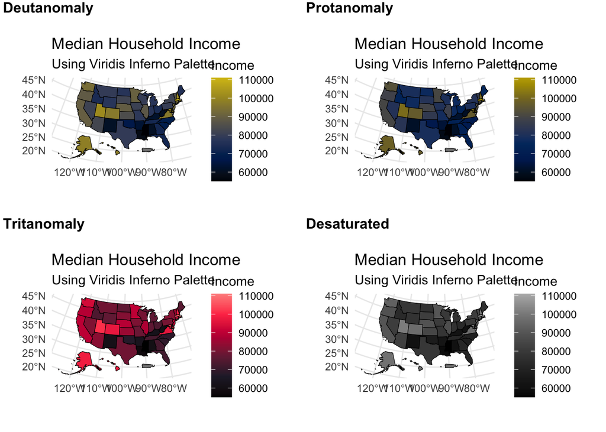

```r
us_income_map <- ggplot(data = us_states_income) +
  geom_sf(aes(fill = Income), color = "black", size = 0.3) +
  scale_fill_viridis_c(option = "inferno", end = .8) +
  theme_minimal() +
  labs(title = "Median Household Income",
       fill = "Income",
       subtitle = "Using Viridis Inferno Palette")

cvd_grid(us_income_map)
```

- Yes there are problems with the original colors scheme the purples and blues would are too close in color and would not be able to be told apart. To make the map more accessible the scale_fill_viridis_c function can be used to make the map color blind friendly.

  b. Wilke discusses color vision deficiency in [section 19.3](https://clauswilke.com/dataviz/color-pitfalls.html#not-designing-for-color-vision-deficiency) of his book. Try using the [Okabe-Ito scale](https://malcolmbarrett.github.io/ggokabeito/) recommended in that section on your map. Does it improve your map? Why or why not?

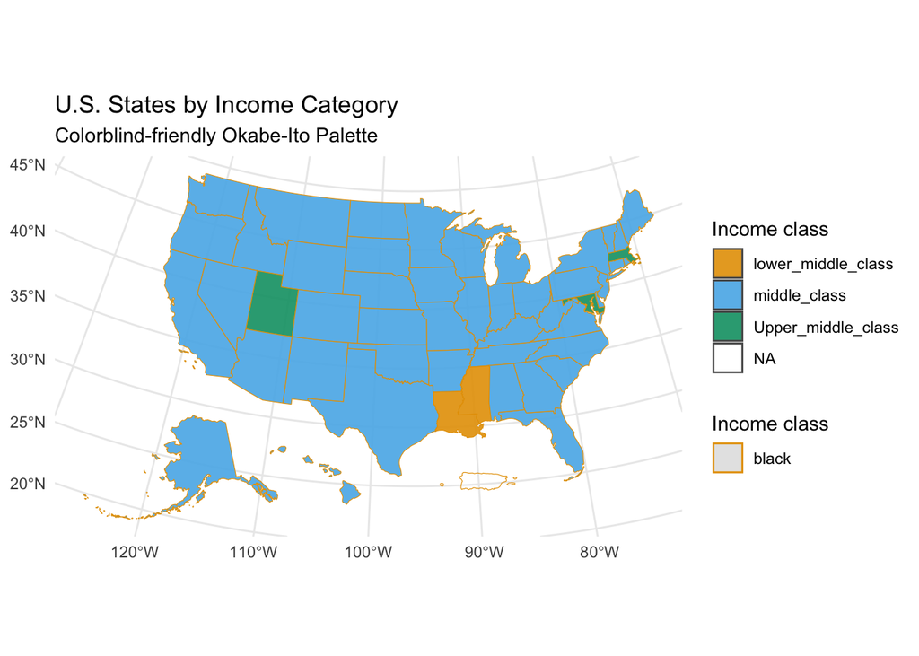

  ```r
  ggplot(data = us_states_income) +
    geom_sf(aes(fill = income_class, color = "black"), size = 0.3) +
    scale_fill_okabe_ito(name = "Income class", alpha = 0.9) +
    scale_color_okabe_ito(name = "Income class") +
    theme_minimal() +
    labs(title = "U.S. States by Income Category",
         subtitle = "Colorblind-friendly Okabe-Ito Palette",
         fill = "Income Category")
  ```

- The colors on the map are more vibrant making them easier to see for color vision deficiency. Also the outlier states stick out more with the vibrant colors.